# Project Component 4 - Test the model and show it on github

Varshini Kamaraj

### 1. A refined statement of the model’s purpose and application from project Component 1.

BikePGH is a non-profit group based in Pittsburg that advocates for bikeable and walkable streets in Pittsburg. In September 2016 Uber made Pittsburg the first place where ride share users could use a self-driving vehicle. BikePGH noticed an influx of comments/complaints from people who were experiencing the presence of Automated Vehicles(AVs) on the streets of Pittsburg. To better understand the publics perception of AVs and to initiate a conversation about the use of AVs and its testing, BikePGH conducted a survey to understand how pedestrians and bicyclists felt about sharing the streets with AVs.

The surveys that were conducted consisted of questions which requested open-ended comments as well. For example, one question asked: “What do you think BikePGH’s position on AVs should be? Please elaborate on this”. Analysing such questions can give developers of AVs and policy makers a better understanding of the publics perception of AVs and also give rise to potential changes in the design and operation of AVs.

Manual analysis of these comments is a tedious process. One way to overcome this is to take advantages of unsupervised learning methods for content analyis of text data. Structural topic modeling(STM) is a popular framework that allows researchers to discover topics in text data. Structural topic modeling can be conducted using STM, an R package that has functions for conducting each stage of structural topic modeling. The goal of using STM on the dataset is in hopes of finding insights from the public that could help redefine the way in which AVs are designed and operated.

### 2. A refined statement of the data used in the model, as well as transformations and abstractions you performed.

The survey was conducted by BikePGH in two parts. One survey was conducted exclusively for donor-members and received 321 responses. Another survey was conducted to receive responses from the general public and this received 798 responses.

The survey consisted of both open-ended and closed-ended questions. Open-ended questions give responders the opportunity to answer in sentences and express their thoughts. These responses often give more insight into the problem being researched. Closed-ended questions can be answered by selecting an answer from list of possible answers. For example answers like “Yes” or “No” or ratings from 1-5.

In analyzing the BikePGH survey data, both the closed-ended and open-ended question responses were analyzed.

**Closed-ended Questions** There were totally 23 variables in the datafile. A data dictionary was provided with the data files. In order to clean the data, the name of the variables were changed to be the same as the variables names listed in the data dictionary. Variables that were unnecessary to the analysis like start date/end date/ zipcode were removed. Open-ended comments are also filtered out as well as this section is only concerned with analyzing closed-ended responses. Responses with NA were also removed.

After cleaning the dataset, there were 14 variables with 793 observations. Count and mutate operations were used to find the percentage of the responses to a particular question.

**Open-ended Questions** Open-ended responses also need to be cleaned before analysis. The STM package included functions that can be used for cleaning the data. First, the excel file containing the responses are imported into R. The STM package consists of a function called textProcessor() which can be used to process the text data. The pre-processing of the text data typically includes stemming (reducing works to their root form), dropping punctuations and stop word removal(removing words like ‘the.’ The textProcessor() function is capable of performing all three steps. Another step in cleaning the open-ended responses involves removing words that do not appear frequently in the text. This can be achieved using the prepDocuments() function by setting a parameter named lower.thresh. Before setting the lower threshold value another function called plotRemoved() can be used to plot the number of words and documents that will be removed for different threshold values.

### 3. A refined statement about its validity and generalizability.

In evaluating the algorithm it is important to assess if the algorithm is reliable and valid. Here reliability implies if the model is repeatable. In order to get repeatable results, a seed can be set in the algorithm to get repeatable results.

Validity refers the correctness of the model. This brings us to one of the limitations of topic modeling. Topic modeling cannot be used to arrive at a accurate number of topics to describe the data. For instance, the number of topics is left to the user to decide. In the STM package the function searchK() can be used to select the number of topics. However, these functions are only data-driven approaches that are intended to guide the user and not give a definitive answer for the number topics. Thus, it is necessary for the user to have a theoritical understanding of the data while deciding on the number of topics.

### 4. A refined graphical depiction of the most revealing and interesting element of the model

There are two depictions in the model that I personally found interesting.

1. Using the findThoughts() function to get the comments that represent the topic. This gave a better sense of the way the topics were classified.
2. Using the stmCorrViz() function that generates an interactive visualization of the topic hierarchies. The resulting visualization can be seen in a web browser.

The use of both these functions can be found in Step 9. The file for the interactive visualization can be found in the github repository. _______________________________________________________________________________________________________

**Step 1: Load all necessary libraries, import data and clean up**

```r
#Loading at necessary Libraries
library(ggpubr)
library(ggrepel)
library(knitr)
library(tidyr)
library(stringr)
library(ggplot2)
library(scales)
library(ggthemes)
library(readxl)
library(tidyverse)
library(stm)        # Package for sturctural topic modeling
library(igraph)     # Package for network analysis and visualisation
library(stmCorrViz) # Package for hierarchical correlation view of STMs
library(rPref)      # For pareto frontier
library(wordcloud)
# Importing excel file with data
#Importing excel file
data <- read_excel("AV_Public_Variables.xls")
# Adding a column for the document number
data <- data %>% mutate(document_no = row_number())
# Subsetting the dataframe : Not all the columns are of interest. I'm only interested in people's views on what bikePHG's position should be on AVs
# SafetyAV - On a typical day, how safe do you feel using Pittsburgh's streets with autonomous vehicles? (1 being "very unsafe"; and 5 being "very safe")
# BikePghElaborate - What do you think BikePGH's position on AVs should be? Please Elaborate on this
data <- data %>% select(document_no,BikePghElaborate,SafetyAV) %>% drop_na() %>% filter(SafetyAV != "No experience")
```

**Step 2 : For data preparation, first, stemming and stopword removal were done using the textProcessor() function:**

```r
processed <- textProcessor(data$BikePghElaborate, metadata=data,lowercase = TRUE,removestopwords = TRUE,
                           removenumbers = TRUE, removepunctuation = TRUE,stem = TRUE, sparselevel = 1,
                           language = "en", verbose = FALSE, onlycharacter = FALSE,
                           striphtml = FALSE, customstopwords = NULL, v1 = FALSE)
```

**Step 3: The plotRemoved function can be used to test different threshold value for getting an idea of how many documents, words and tokens are removed based on the threshold value.**

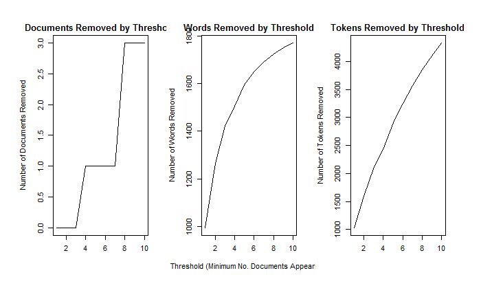

```r
plotRemoved(processed$documents, lower.thresh = seq(1,10,by=1))
```

**Step 4: After analysis of the plotRemoved graphs, a lower threshold value can be selected and the documents can be prepped as follows. After that save the output object meta, documents, and vocab into variables:**

```r
out <- prepDocuments(processed$documents, processed$vocab, processed$meta,lower.thresh = 4,verbose= FALSE)
# Saving
docs <- out$documents
vocab <- out$vocab
meta <- out$meta
```

**Step 5: Before using the stm function, the STM package has a function called searchK to help the user find the number of topics(use this as a reference, not a substitute for human judgement). A pareto plot can then be made to get a better idea**

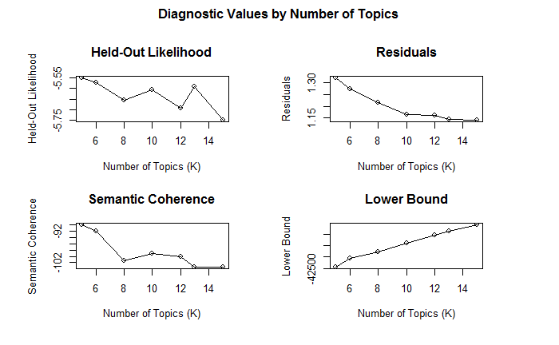

```r
findingk <- searchK(out$documents, out$vocab,
                    K = c(5,6,8,10,12,13,15),
                    prevalence =~ SafetyAV, data = meta, verbose=FALSE, seed = 500 )
plot(findingk)
```

**Step 6: PLotting the Pareto curves : Exclusivity and Coherence**

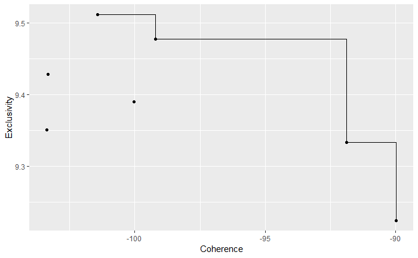

```r
findingk_Results = findingk$results
sky = psel(findingk_Results,high(semcoh)*high(exclus))
cohExcplot = ggplot(findingk_Results,aes(semcoh,exclus)) +
  geom_point() +
  geom_text_repel(aes(label=K))+
  geom_step(data = sky,direction = "hv")+
  labs(y="Exclusivity",x = "Coherence")
cohExcplot
```

**Step 7: PLotting the Pareto curves :Heldout Likelihood and Lowerbound of marginal likelihood**

[figure not shown]

```r
sky <- psel(findingk_Results,high(heldout)*high(bound))
LikelihoodBoundPlot = ggplot(findingk_Results,aes(heldout,bound))+
  geom_point()+
  geom_text_repel(aes(label=K))+
  geom_step(data = sky,direction="hv")+
  labs(y="Heldout Likelihood",x= "Lower Bound of Marginal Likelihood")
LikelihoodBoundPlot
```

**Step 8 : Now using the STM function to find the topics**

```r
pittFit <- stm(out$documents, out$vocab, K=6, prevalence=~SafetyAV,
                       max.em.its=400, data=out$meta, init.type="Spectral",
                       seed=500,verbose = FALSE)
```

The summary model with 6 topics

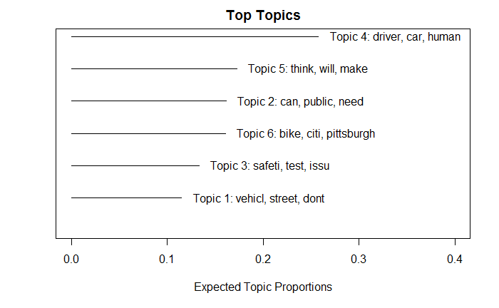

```r
plot(pittFit, type="summary", xlim=c(0,.4))
```

The most frequent words in the model such as for the topics

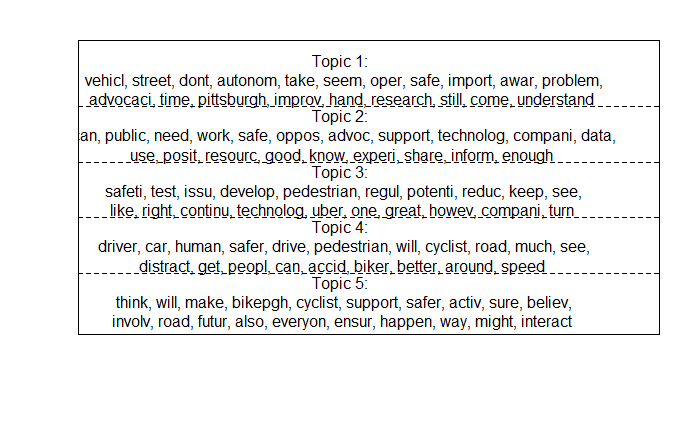

```r
print_topics <- plot(pittFit, type="labels", topics=c(1,2,3,4,5))
```

**Step 9: Interpreting the results is this step. It can be done in various ways. Results can also be visualized using a word cloud.**

-One way is to display words associated with topics..use labelTopics() -topicCorr() STM permits correlations between topics.

Lets look only at labelTopics() and topicCorr () and then plot a word cloud for one of the topics

```r
#Label Topics
labelTopicsSel <- labelTopics(pittFit,c(1,2,3,4,5,6))
labelTopicsSel
```

```
Topic 1 Top Words:
     Highest Prob: vehicl, street, dont, autonom, take, seem, oper
     FREX: vehicl, hand, import, seem, dont, problem, oper
     Lift: collect, hand, motor, replac, tell, track, wait
     Score: vehicl, tell, dont, autonom, oper, street, seem
Topic 2 Top Words:
     Highest Prob: can, public, need, work, safe, oppos, advoc
     FREX: public, oppos, advoc, data, posit, experi, live
     Lift: anyon, easier, effort, engag, experi, fight, invest
     Score: next, data, advoc, oppos, public, work, interest
Topic 3 Top Words:
     Highest Prob: safeti, test, issu, develop, pedestrian, regul, potenti
     FREX: issu, develop, test, safeti, turn, reduc, continu
     Lift: allow, ask, avoid, cours, develop, failur, input
     Score: turn, test, safeti, develop, issu, regul, reduc
Topic 4 Top Words:
     Highest Prob: driver, car, human, safer, drive, pedestrian, will
     FREX: driver, human, drive, distract, around, far, hit
     Lift: alway, close, cross, decreas, distract, far, ive
     Score: driver, human, drive, monitor, distract, phone, hit
Topic 5 Top Words:
     Highest Prob: think, will, make, bikepgh, cyclist, support, safer
     FREX: sure, involv, think, everyon, happen, make, might
     Lift: everyon, determin, differ, goal, happen, might, opportun
     Score: think, bikepgh, will, protect, cyclist, make, sure
Topic 6 Top Words:
     Highest Prob: bike, citi, pittsburgh, pgh, bicyclist, transport, need
     FREX: bike, just, lane, focus, group, citi, transport
     Lift: infrastructur, money, polit, realiti, bike, area, first
     Score: bike, practic, pgh, transport, citi, part, infrastructur
```

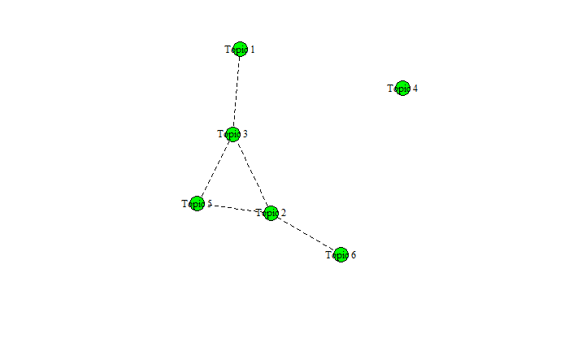

```r
#Topic Correlations
topicorrel <- topicCorr(pittFit)
plot(topicorrel)
```

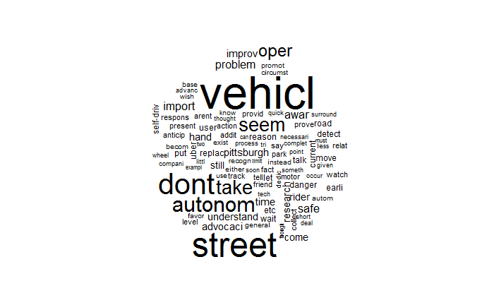

```r
# Word cloud
cloud(pittFit, topic=1)
```

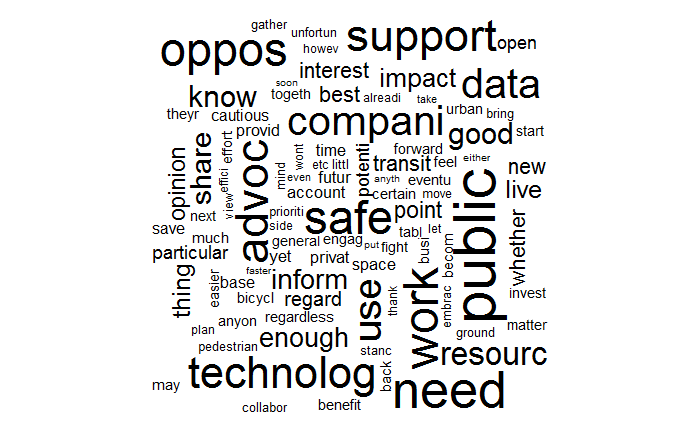

```r
cloud(pittFit, topic=2)
```

[figure not shown]

```r
cloud(pittFit, topic=3)
```

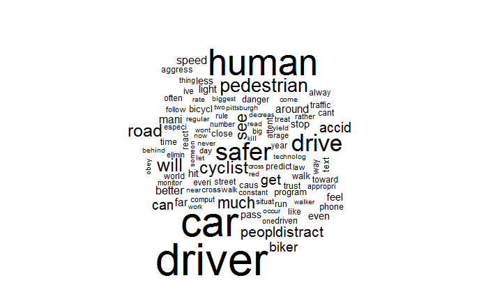

```r
cloud(pittFit, topic=4)
```

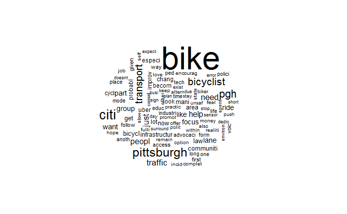

```r
#cloud(pittFit, topic=5) some words did not fit on page
cloud(pittFit, topic=6)
```

Also using findThoughts()

```
argument is not an atomic vector; coercingargument is not an atomic vector; coercing
```

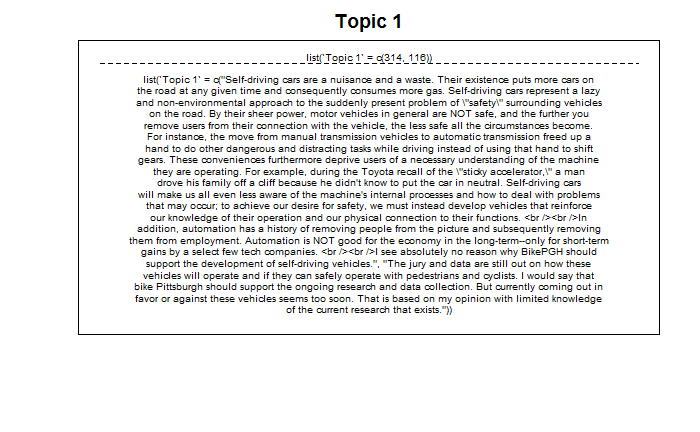

```r
# Non supportive
thoughts1 <- findThoughts(pittFit, texts=meta$BikePghElaborate, n=2, topics=1)
plotQuote(thoughts1, width=100,text.cex = 0.6, main="Topic 1")
```

```
argument is not an atomic vector; coercingargument is not an atomic vector; coercing
```

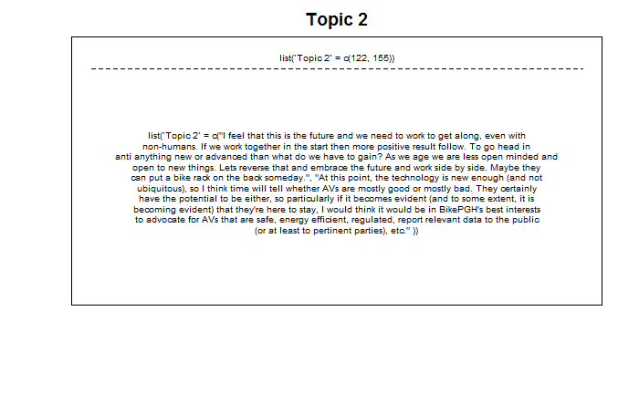

```r
# Embrace and work together pro-advocacy
thoughts2 <- findThoughts(pittFit, texts=meta$BikePghElaborate, n=2, topics=2)
plotQuote(thoughts2, width=100,text.cex = 0.6, main="Topic 2")
```

```
argument is not an atomic vector; coercingargument is not an atomic vector; coercing
```

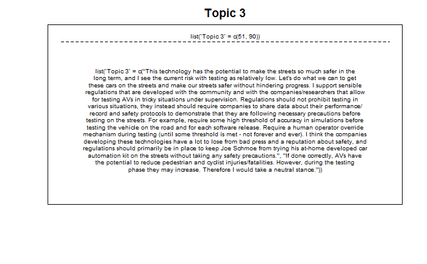

```r
# Potential to reduce risk
thoughts3 <- findThoughts(pittFit, texts=meta$BikePghElaborate, n=2, topics=3)
plotQuote(thoughts3, width=100,text.cex = 0.6, main="Topic 3")
```

```
argument is not an atomic vector; coercingargument is not an atomic vector; coercing
```

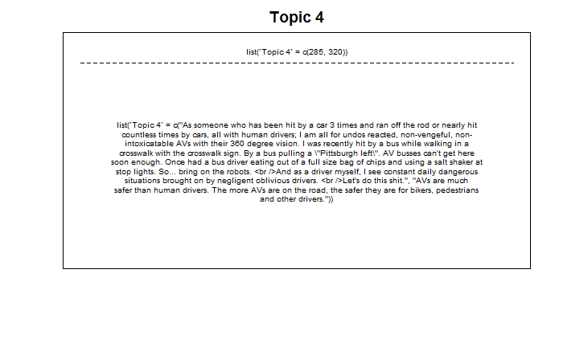

```r
# AVs are safer
thoughts4 <- findThoughts(pittFit, texts=meta$BikePghElaborate, n=2, topics=4)
plotQuote(thoughts4, width=100,text.cex = 0.6, main="Topic 4")
```

```
argument is not an atomic vector; coercingargument is not an atomic vector; coercing
```

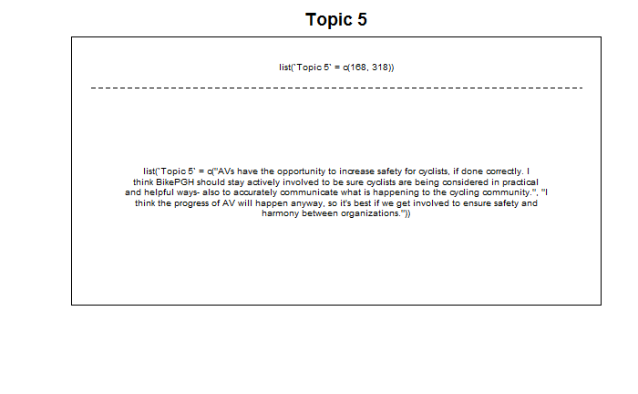

```r
# BikePGH should get involved
thoughts5 <- findThoughts(pittFit, texts=meta$BikePghElaborate, n=2, topics=5)
plotQuote(thoughts5, width=100,text.cex = 0.6, main="Topic 5")
```

```
argument is not an atomic vector; coercingargument is not an atomic vector; coercing
```

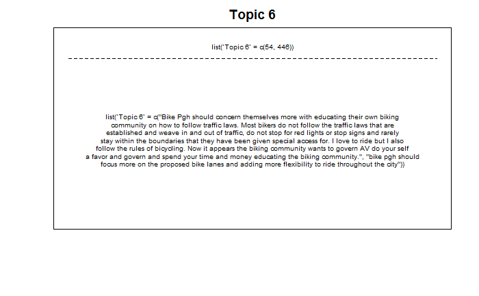

```r
# BikePGH should stick to bikes
thoughts6 <- findThoughts(pittFit, texts=meta$BikePghElaborate, n=2, topics=6)
plotQuote(thoughts6, width=100,text.cex = 0.6, main="Topic 6")
```

Another visualization technique that was interesting was using library(stmCorrViz) which is a package #for hierarchical correlation view of STMs.

```r
stmCorrViz(pittFit,"PGH_stm_interactive_correlation.html",documents_raw=meta$BikePghElaborate,documents_matrix=out$documents)
```